# Stats 506, F18, Problem Set 3

Xinye Jiang (xinyej@umich.edu)

November 17, 2018

## Question 1

### a.

**Table 1.** *Proportion of homes having stucco construction as the major outside wall material by division.* Each row shows the proportion with 95% CI for one division. Rows are sorted by the proportion.

| Division | Proportion (%) | 95% CI (%) |
| --- | --- | --- |
| Mountain South | 64.25 | ( 55.45, 73.05) |
| Pacific | 44.59 | ( 41.28, 47.89) |
| Mountain North | 16.61 | ( 10.25, 22.96) |
| South Atlantic | 10.62 | ( 7.83, 13.40) |
| West North Central | 4.87 | ( 0.89, 8.84) |
| West South Central | 2.99 | ( 1.63, 4.35) |
| Middle Atlantic | 2.06 | ( 0.62, 3.50) |
| New England | 1.23 | ( 0.00, 2.80) |
| East North Central | 0.66 | ( 0.10, 1.21) |
| East South Central | 0.42 | ( 0.00, 1.22) |

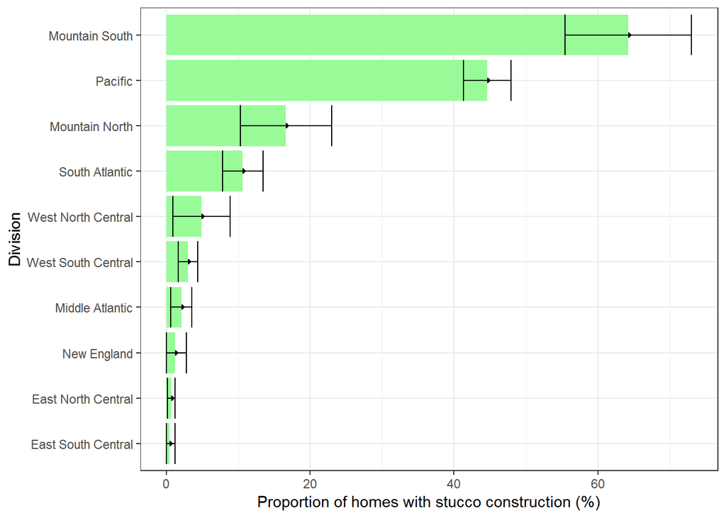

**Figure 1.** *Proportion of homes having stucco construction as the major outside wall material by division.*

The percent of homes having stucco construction as the major outside wall material within each division with its 95% CI is shown in Table 1 and Figure 1. Mountain South division had the highest proportion, and East South Central division had the lowest proportion.

### b.

**Table 2.** *Average total electricity usage in kilowatt hours in each division.* Each row shows the average total electricity usage with its 95% CI for one division. Rows are sorted by the average total electricity usage.

| Division | Average Total Electricity Usage, kwh/home | 95% CI |
| --- | --- | --- |
| East South Central | 14535.97 | (13319.56, 15752.38) |
| West South Central | 14324.26 | (13495.11, 15153.41) |
| South Atlantic | 13446.62 | (12903.94, 13989.30) |
| West North Central | 10523.83 | (9634.74, 11412.91) |
| Mountain South | 10442.02 | (7950.13, 12933.91) |
| East North Central | 9128.66 | (8729.56, 9527.76) |
| Middle Atlantic | 8465.44 | (8071.30, 8859.58) |
| Mountain North | 8384.47 | (7121.41, 9647.53) |
| Pacific | 8100.41 | (7750.36, 8450.45) |
| New England | 7514.56 | (6471.83, 8557.30) |

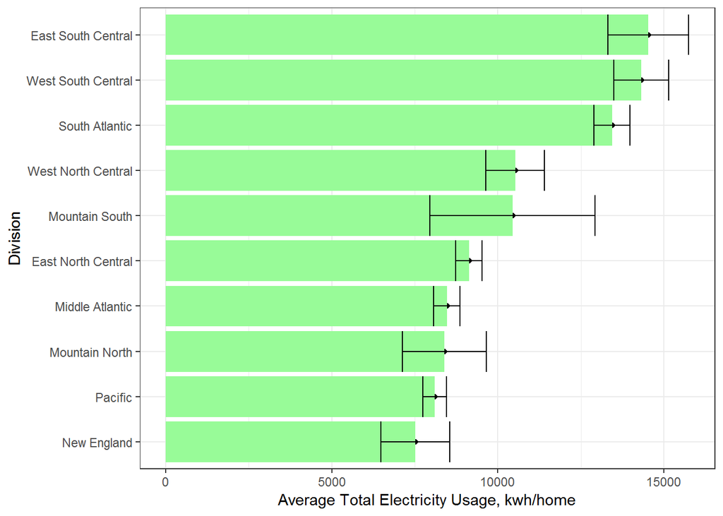

**Figure 2.** *Average total electricity usage in kilowatt hours in each division.*

The average total electricity usage in kilowatt hours in each division with its 95% CI is shown in Table 2 and Figure 2. East South Central had the largest average total electricity usage, while New England had the smallest.

**Table 3.** *Average total electricity usage in kilowatt hours stratified by urban and rural status in each division.* Each row shows the average total electricity usage with its 95% CI for each status in one division. Rows are sorted by the average total electricity usage in Rural status.

| Division | Rural, kwh/home | Rural 95% CI | Urban, kwh/home | Urban 95% CI |
| --- | --- | --- | --- | --- |
| East South Central | 16333 | ( 14088, 18578) | 13747 | ( 12197, 15298) |
| West South Central | 16317 | ( 14067, 18567) | 13629 | ( 12852, 14405) |
| South Atlantic | 15942 | ( 14839, 17045) | 12725 | ( 12134, 13316) |
| West North Central | 14174 | ( 12608, 15740) | 9467 | ( 8722, 10211) |
| Pacific | 14115 | ( 12001, 16229) | 7349 | ( 6905, 7793) |
| East North Central | 13500 | ( 12022, 14978) | 7980 | ( 7552, 8408) |
| Middle Atlantic | 12223 | ( 10633, 13814) | 7987 | ( 7659, 8316) |
| Mountain North | 9356 | ( 5698, 13014) | 8099 | ( 7396, 8803) |
| New England | 9001 | ( 6766, 11236) | 6964 | ( 5918, 8010) |
| Mountain South | 8610 | ( 6536, 10685) | 10743 | ( 8178, 13308) |

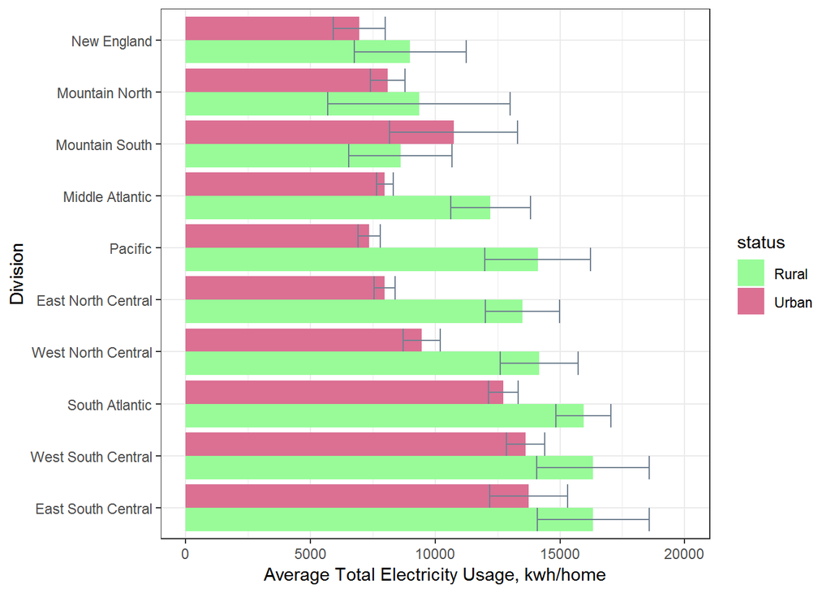

**Figure 3.** *Average total electricity usage in kilowatt hours stratified by urban and rural status in each division.*

The average total electricity usage in kilowatt hours stratified by urban and rural status with its 95% CI in each division is shown in Table 3 and Figure 3. Rural place had larger average total electricity usage than Urban place in all regions except for Mountain South.

### c.

**Table 4.** *Disparity between urban and rural areas in terms of the proportion of homes with internet access in each division.* Each row shows the proportion for each status and disparity with their 95% CIs in one division. Rows are sorted by the proportion disparity.

| Divison | Disparity (%) | 95% CI | Rural (%) | Rural 95% CI | Urban (%) | Urban 95% CI |
| --- | --- | --- | --- | --- | --- | --- |
| Mountain South | 18.5 | ( 7.2, 29.8) | 66.7 | ( 58.3, 75.2) | 85.3 | ( 81.3, 89.2) |
| East South Central | 9.3 | ( -1.4, 20.1) | 69.0 | ( 63.5, 74.6) | 78.4 | ( 70.5, 86.2) |
| West North Central | 7.7 | ( -2.5, 17.8) | 80.3 | ( 71.5, 89.2) | 88.0 | ( 84.6, 91.4) |
| Mountain North | 5.5 | ( -6.2, 17.2) | 81.9 | ( 73.8, 90.0) | 87.4 | ( 82.0, 92.9) |
| West South Central | 5.1 | ( -2.3, 12.5) | 76.5 | ( 72.1, 80.9) | 81.6 | ( 76.4, 86.8) |
| Pacific | 3.4 | ( -4.5, 11.4) | 85.3 | ( 77.4, 93.1) | 88.7 | ( 86.2, 91.2) |
| South Atlantic | 3.3 | ( -3.5, 10.1) | 82.0 | ( 76.3, 87.8) | 85.3 | ( 82.6, 88.0) |
| New England | 1.8 | ( -2.5, 6.0) | 85.8 | ( 82.4, 89.2) | 87.6 | ( 82.5, 92.6) |
| East North Central | 0.0 | ( -5.3, 5.4) | 86.2 | ( 81.6, 90.8) | 86.3 | ( 83.8, 88.7) |
| Middle Atlantic | -1.9 | ( -9.1, 5.2) | 91.3 | ( 85.3, 97.3) | 89.3 | ( 83.9, 94.8) |

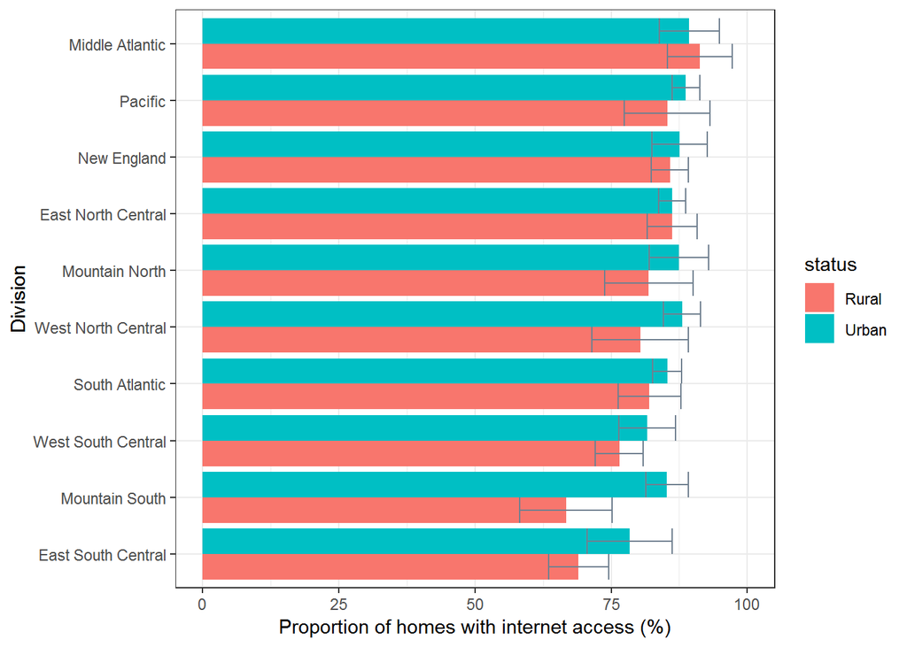

**Figure 4.** *Disparity between urban and rural areas in terms of the proportion of homes with internet access in each division.*

From the output in Table 4 and Figure 4, we can see that Mountain South division has the largest disparity between urban and rural areas in terms of the proportion of homes with internet access.

### d.

The question formulated is stated below:

What is the percent of homes of mobile home type within each region? Which region has the highest proportion? Which has the lowest?

**Table 5.** *Proportion of homes of mobile home type in each region.* Each row shows the proportion with 95% CI for one region. Rows are sorted by the proportion.

| Region | Proportion (%) | 95% CI (%) |
| --- | --- | --- |
| South | 8.73 | ( 8.73, 8.73) |
| West | 5.44 | ( 5.44, 5.44) |
| Midwest | 3.72 | ( 3.72, 3.72) |
| Northeast | 2.33 | ( 2.33, 2.33) |

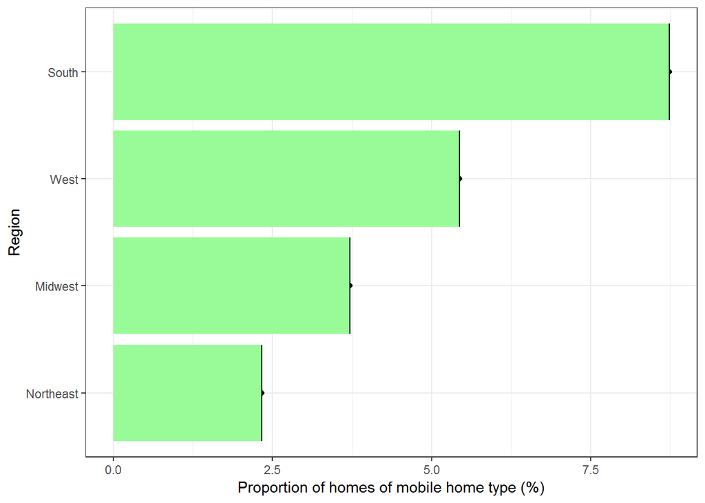

**Figure 5.** *Proportion of homes of mobile home type in each region.*

The percent of homes of mobile home type with its 95% CI in each division is shown in Table 5 and Figure 5. South region had the highest proportion, and Northeast region had the lowest proportion. Proportions are all smaller than 10% and have very small standard errors which can be seen from the small ranges of CIs.

## Question 2

Choose the covariance matrix of X as a p by p diagonal matrix whose diagonal entries are all 1 and choose the sigma of Y as 1.

**Table 6.** *Monte Carlo estimates in (%) for the family wise error rate, the false discovery rate, the sensitivity and the specificity for the uncorrected and several corrected sets of p-values adjusted by different methods.* Each row shows the Monte Carlo estimates for one set of p-values.

|  | Family wise error rate (%) | False discovery rate (%) | Sensitivity (%) | Specificity (%) |
| --- | --- | --- | --- | --- |
| Uncorrected | 98.9 | 31.410 | 100 | 94.268 |
| Bonferroni | 9.0 | 0.908 | 100 | 99.887 |
| Holm | 9.0 | 0.908 | 100 | 99.887 |
| BH | 43.7 | 6.643 | 100 | 99.022 |
| BY | 12.5 | 1.895 | 100 | 99.738 |

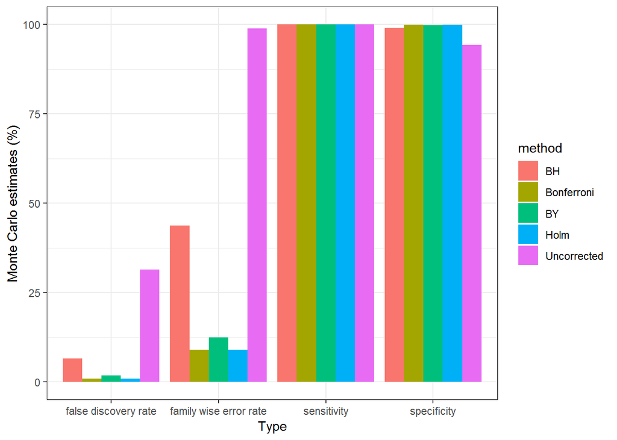

**Figure 6.** *Monte Carlo estimates in (%) for the family wise error rate, the false discovery rate, the sensitivity and the specificity for the uncorrected and several corrected sets of p-values adjusted by different methods.*

The above table and figure show the family wise error rate, the false discovery rate, the sensitivity and the specificity for the uncorrected and several corrected sets of p-values adjusted by the methods of ‘Bonferroni’, ‘Holm’, ‘BH’ (Benjamini-Hochberg), and ‘BY’ (Benjamini-Yekuteli). The uncorrected p-values set has the largest family wise error rate and false discovery rate, and after corrections, these two rates decrease significantly. Compare the performance of different correction methods, we can see that “BH” has the largest family wise error rate and false discovery rate among the correction methods, while “Bonferroni” and “Holm” have the smallest. The sensitivities are all extremely large, and so are the specificities.

## Question 3

### a.

**Table 7.** *The estimated univariate regression coefficients by group for three independent variables disp, hp and wt using “data.table” .* Each row shows the estimated univariate regression coefficients for these three variables in one group.

| cyl (group) | beta for disp | beta for hp | beta for wt |
| --- | --- | --- | --- |
| 4 | -0.1351 | -0.1128 | -5.6470 |
| 6 | 0.0036 | -0.0076 | -2.7801 |
| 8 | -0.0196 | -0.0142 | -2.1924 |

### b.

**Table 8.** *The estimated univariate regression coefficients by group for three independent variables disp, hp and wt using the function written in b.* Each row shows the estimated univariate regression coefficients for these three variables in one group.

| cyl (group) | beta for disp | beta for hp | beta for wt |
| --- | --- | --- | --- |
| 4 | -0.1351 | -0.1128 | -5.6470 |
| 6 | 0.0036 | -0.0076 | -2.7801 |
| 8 | -0.0196 | -0.0142 | -2.1924 |

Test column by column whether the results are the same:

```
## [1] TRUE TRUE TRUE
```

The function produces the same results as in part a.

### c.

**Table 9.** *The estimated univariate regression coefficients by group for three independent variables disp, hp and wt using the dplyr verb “summarize_at()” .* Each row shows the estimated univariate regression coefficients for these three variables in one group.

| cyl (group) | beta for disp | beta for hp | beta for wt |
| --- | --- | --- | --- |
| 4 | -0.1351 | -0.1128 | -5.6470 |
| 6 | 0.0036 | -0.0076 | -2.7801 |
| 8 | -0.0196 | -0.0142 | -2.1924 |

The table has the same results as in part a.

### d.

**Table 10.** *The estimated univariate regression coefficients by group for three independent variables disp, hp and wt using the function written in d.* Each row shows the estimated univariate regression coefficients for these three variables in one group.

| cyl (group) | beta for disp | beta for hp | beta for wt |
| --- | --- | --- | --- |
| 4 | -0.1351 | -0.1128 | -5.6470 |
| 6 | 0.0036 | -0.0076 | -2.7801 |
| 8 | -0.0196 | -0.0142 | -2.1924 |

Test column by column whether the results are the same:

```
## [1] TRUE TRUE TRUE
```

The function produces the same results as in part a.